# Silica

Katie Willi

## Aggregating

```r
raw_silica <- raw_silica %>%
  dplyr::select(date=ActivityStartDate,
                parameter=CharacteristicName,
                parm_cd=USGSPCode,
                units=ResultMeasure.MeasureUnitCode,
                SiteID=MonitoringLocationIdentifier,
                org=OrganizationFormalName,
                org_id=OrganizationIdentifier,
                time=ActivityStartTime.Time,
                value=ResultMeasureValue,
                sample_method=SampleCollectionMethod.MethodName,
                analytical_method=ResultAnalyticalMethod.MethodName,
                particle_size=ResultParticleSizeBasisText,
                date_time=ActivityStartDateTime,
                media=ActivityMediaName,
                type=ActivityMediaSubdivisionName,
                sample_depth=ActivityDepthHeightMeasure.MeasureValue,
                sample_depth_unit=ActivityDepthHeightMeasure.MeasureUnitCode,
                fraction=ResultSampleFractionText,
                status=ResultStatusIdentifier,
                field_comments=ActivityCommentText,
                lab_comments=ResultLaboratoryCommentText,
                result_comments=ResultCommentText) %>%
  left_join(p_codes, by='parm_cd') %>%
  mutate(year=year(date),
         units = trimws(units)) %>%
  filter(year >= 1984) %>%
  filter(media%in%c("Water","water")) %>%
  filter(type%in%c('Surface Water','Water','Estuary','Ocean Water','Mixing Zone')|is.na(type)) %>%
  rowid_to_column(.,"index")

# DATA LUMPING

aggregated_methods <- raw_silica %>%
  mutate(method_status = case_when(

    # Silica-specific:
    grepl("4500-SiO2 C|4500 SiO2-C|4500 Si-C|4500 Si C|
          4500C|4500 C|4500-SiC|4500-SI02 C|4500 SIO2 C|
          4500-SIO2C",
          analytical_method,ignore.case=T) ~ "Molybdosilicate Method",

    grepl("4500-SiO2 D|4500 SiO2-D|4500 Si-D|4500 Si D|
          4500D|4500 D|4500-SiD",
          analytical_method,ignore.case=T) ~ "Heteropoly Blue Method",

    grepl("370.1",
          analytical_method,ignore.case=T) ~ "EPA Method 370.1",

    grepl("4500-SiO2 E|4500 SiO2-E|4500 Si-E|4500 Si E|4500E|
          4500 E|4500-SiE|Technicon Industrial Method 105-71|
          4500 SIO2 E",
          analytical_method,ignore.case=T) ~ "Automated Method for Molybdate-Reactive Silica",

    grepl("4500-SiO2 F|4500 SiO2-F|4500 Si-F|4500 Si F|4500F|
          4500 F|4500-SiF|4500 SIO2 F",
          analytical_method,ignore.case=T) ~ "Flow Injection Analysis for Molybdate-Reactive Silicate",

    grepl("366",analytical_method,ignore.case=T) ~ "EPA Method 366.0",

    # Inorganic/Metals general (many of these  do not list Si specifically, though SM section 4500 lists them as appropriate methods):
    grepl("3111 D|3111-D|Nitrous Oxide|FLAA",
          analytical_method,ignore.case=T) ~ "Direct Nitrous Oxide-Acetylene Flame Method",

    grepl("3120|200.7|6010|Plasma Emission Spectrosc|ICP-AES|ICP AES|
          ICP-OES|ICP-OES|ICP OES|ICP/OES|Inductively Coupled Plasma AES|
          Atomic Emission Spec|Optical Emission Spec|Atomic Emission Spectrometry", # is this real though
          analytical_method,ignore.case=T) ~ "ICP-AES",

    grepl("3113|Atomic Absorption|GFAA|graphite furnace",
          analytical_method,ignore.case=T) ~ "Electrothermal Atomic Absorption Spectrometric Method",

    grepl("3125|200.8|ICP/MS|ICP MS|ICP-MS|plasma/mass spec",
          analytical_method,ignore.case=T) ~ "ICP/MS",

    # General-ass ICP
    grepl("Silica in Water by ICP| ICP, EPA method|ICP Package",
          analytical_method,ignore.case=T) ~ "Just ICP"))

grouped_more <- aggregated_methods %>%
  mutate(grouped=ifelse(method_status %in%
                          c('Molybdosilicate Method',
                            'Heteropoly Blue Method',
                            'EPA Method 370.1',
                            'EPA Method 366.0',
                            'Automated Method for Molybdate-Reactive Silica',
                            'Flow Injection Analysis for Molybdate-Reactive Silicate')|
                          grepl("colorimetr|molybd|colorimeter", analytical_method, ignore.case=T),"Colorimetry", ifelse(is.na(method_status)|method_status=="Ambiguous","Ambiguous",method_status))) %>%
  mutate(grouped=ifelse(method_status %in% c("ICP-AES",
                                             "Just ICP",
                                             "ICP/MS"), "ICP", grouped)) %>%
  mutate(aquasat_fraction=case_when(fraction %in% c('Dissolved','Filtered, lab','Filterable') ~ "Dissolved",
                                    fraction %in% c('Total','Total Recovrble','Total Recoverable','Recoverable','Unfiltered') ~ "Total",
                                    fraction %in% c('Fixed') ~ "Fixed",
                                    fraction %in% c('Non-Filterable (Particle)') ~ 'Particle',
                                    is.na(fraction)|fraction%in%c(" ","Field") ~ "Ambiguous"))

rm(site_url,tables,aggregated_methods,p_codes)
```

### Methods

Silica can be analyzed in a myriad of ways; in the water quality portal, silica had 140 unique analytic methods listed for a total of 981773 samples. However, many of these analytic methods can be grouped together into just a few actual methodologies that are realistic for silica:

- **Colorimetry:** this represents samples that reference the molybdosilicate method (SM 4500 C), the heteropoly blue method (SM 4500 D), the automated method for molybdate-reactive silica (SM 4500 E), flow injection analysis for molybdate-reactive silica (SM 4500 F), gas segmented continuous flow colorimetric analysis (EPA 366.0), spectrophotometric detection of dissolved silica (EPA 370.1), “colorimetry”, or “molybdate”.
- **ICP:** this represents samples that reference ICP/MS (SM 3125, EPA Method 200.8, or “ICP MS”), ICP-AES (SM 3120 , EPA Methods 200.7 and 6010, “ICP AES”, or “ICP OES”), or just “ICP”.
- **Direct Nitrous Oxide-Acetylene Flame Method:** this represents samples that reference SM 3111 D , “Nitrous Oxide”, or “FLAA”
- **Electrothermal Atomic Absorption Spectrometric Method:** this represents samples that reference SM 3113, “GFAA”, or “graphite furnace”.
- All others, which I’m calling **ambiguous**

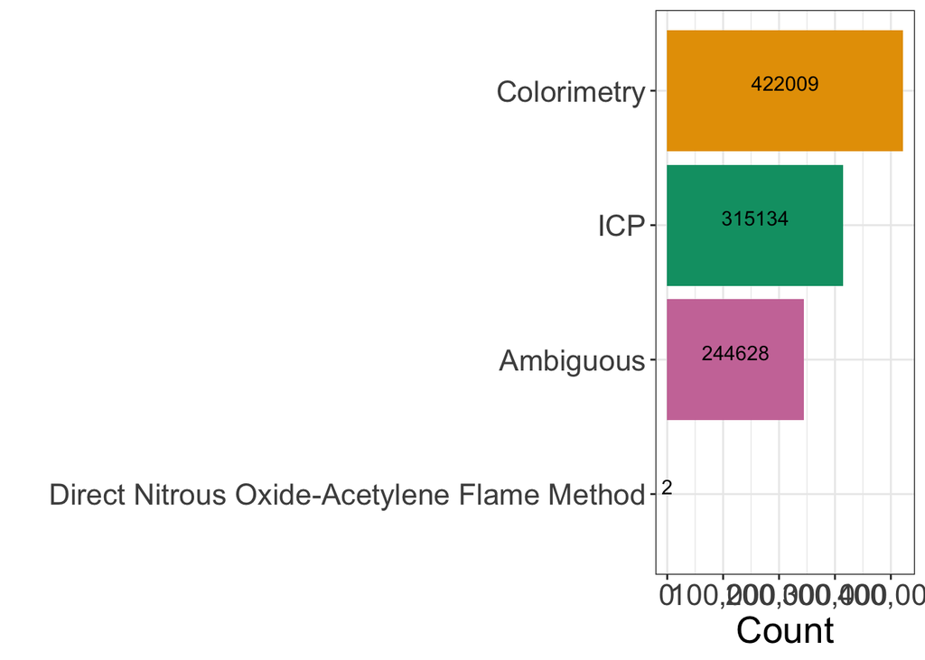

It is clear that colorimetric methods are the most common across grouped methods (at 42.984%).

However, colorimetry encompasses several different types of analytic methods that are defined by either the EPA or SM; there are also a large amount that do not clearly define which colorimetric method was used (i.e., ambiguous but some form of colorimetry):

[figure not shown]

```r
pie <- grouped_more %>%
  filter(grouped=="Colorimetry") %>%
  group_by(method_status) %>%
  summarize(count=n()) %>%
  ungroup() %>%
  mutate(method_status=ifelse(is.na(method_status), "Ambiguous Colorimetry", method_status))
pie <- pie %>% mutate(method_status = factor(x = method_status, levels = method_status)) %>%
  mutate(prop = count/sum(pie$count)) %>%
  mutate(ypos = cumsum(prop)- 0.5*prop) %>%
  mutate(legend = paste0(method_status, " (", percent(prop), ")"))

ggplot(data=pie, aes(x="", y=count, fill=legend)) +
  geom_bar(stat="identity", width=1, color="white") +
  coord_polar("y", start=0) +
  scale_fill_manual(values=c("#009E73","#E69F00","#56B4E9","#CC79A7","#0072B2","#F0E442","#D55E00")) +
  guides(fill=guide_legend(title="Colorimetry Techniques")) +
  theme_void() + # remove background, grid, numeric label
  theme(text = element_text(size = 20))
```

The ICP method is the second most common method for silica analysis, representing 32.098% of all silica samples.

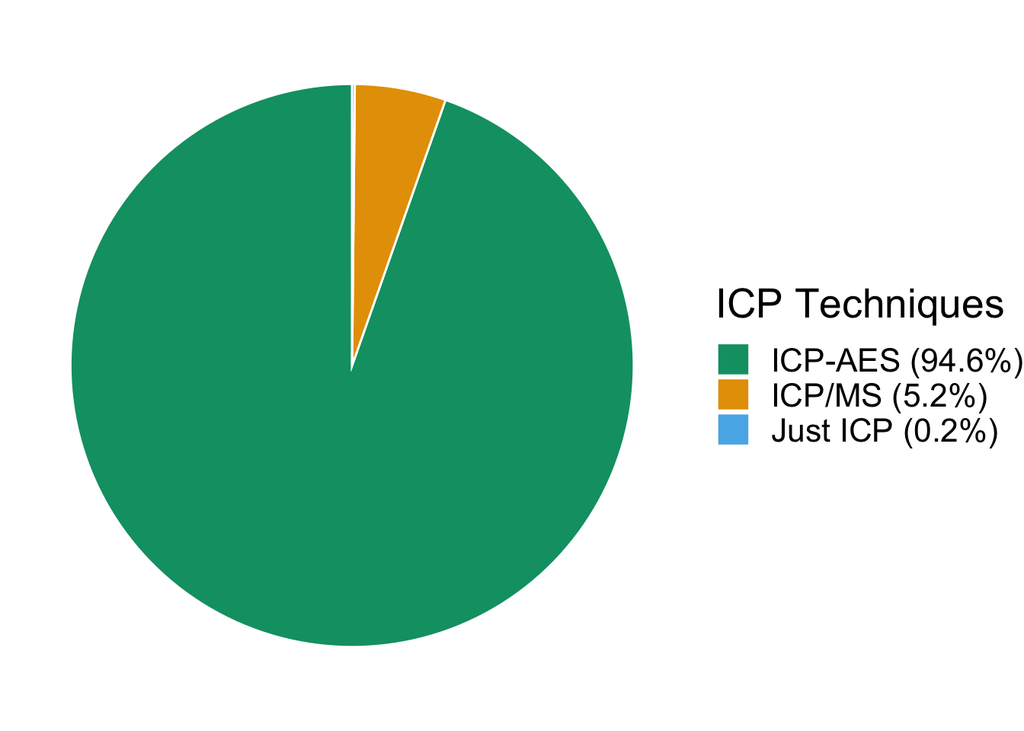

```r
pie <- grouped_more %>%
  filter(grouped=="ICP") %>%
  group_by(method_status) %>%
  summarize(count=n()) %>%
  ungroup() #%>%
#mutate(method_status=ifelse(is.na(method_status), "Ambiguous Colorimetry", method_status))
pie <- pie %>% mutate(method_status = factor(x = method_status, levels = method_status)) %>%
  mutate(prop = count/sum(pie$count)) %>%
  mutate(ypos = cumsum(prop)- 0.5*prop) %>%
  mutate(legend = paste0(method_status, " (", percent(prop), ")"))

ggplot(data=pie, aes(x="", y=count, fill=legend)) +
  geom_bar(stat="identity", width=1, color="white") +
  coord_polar("y", start=0) +
  scale_fill_manual(values=c("#009E73","#E69F00","#56B4E9","#CC79A7","#0072B2","#F0E442","#D55E00")) +
  guides(fill=guide_legend(title="ICP Techniques")) +
  theme_void() + # remove background, grid, numeric label
  theme(text = element_text(size = 20))
```

The third most prevalent aggregated method encompasses samples whose methodologies were too vague to determine how they were analyzed. 24.917% of all samples are considered ambiguous. Below is a table of all methodologies that we considered ambiguous:

```r
grouped_more %>%
  filter(grouped=="Ambiguous") %>%
  group_by(analytical_method) %>%
  summarize(count=dplyr::n()) %>%
  arrange(desc(count)) %>%
  #mutate(grouped=ifelse(is.na(grouped),"Not captured by aggreagting mechanism",grouped)) %>%
  kable(.,'html',caption='Ambiguous Methods') %>%
  kable_styling(position='center') %>%
  scroll_box(width='800px',height='500px')
```

Ambiguous Methods

| analytical_method | count |
| --- | --- |
| NA | 150951 |
| Silica, wf, DA | 16543 |
| Chloride and Silica in Lake Water | 10384 |
| silica | 7738 |
| Silicon, wu,FIA color (USGS-NYL) | 7064 |
| ANL_MTHD | 5586 |
| Flow Injection Analysis by Lachat QuikChem for Silica | 5375 |
| Unknown or Unspecified Procedure | 5301 |
| Gaseous Mercury in Air by CVAA | 4630 |
| Silica, wf, MBC (NY WSC; ALSC) | 4581 |
| Trace elements, wf, ICP/T (Ocala | 2610 |
| Used for half of methods where historical methodology may not be available. | 2410 |
| L01 | 2202 |
| Hawaii historic procedures for Legacy STORET | 1854 |
| UNKNOWN | 1779 |
| WHITLEDGE 1981 | 1760 |
| Lachat FIA 31-114-27-1-A | 1696 |
| SILICA, DISSOLVED (MG/L AS SI02) | 1601 |
| HACH 8185 | 1528 |
| Historic Procedure | 1159 |
| Armstrong et al. 1967 | 851 |
| Metals in Water by ICP | 785 |
| Laboratory Procedures for Water Quality Chemical Analysis | 711 |
| Estero Bay Aquatic Preserve tributary sampling | 697 |
| Silica by HACH DR4000 | 541 |
| Silica | 532 |
| SILICA, TOTAL (MG/L AS SI02) | 512 |
| Unknown | 405 |
| LC3121 | 403 |
| Legacy STORET migration; analytical procedure not specified | 390 |
| Analytical procedure not specified | 363 |
| STANDARD METHODS 4500SI - SILICA | 255 |
| Nutrient analyses from water samples | 248 |
| Not Available | 221 |
| SiO2 | 148 |
| SM204500-SIO2C | 139 |
| Unknown Method or Procedure | 136 |
| AMMONIUM (HANDBOOK OF METHODS FOR ACID DEPOSITION STUDIES) | 100 |
| Silica, wf, MBC (NY WSC; KECK) | 91 |
| CL151 | 61 |
| LEGACY | 49 |
| See QAPP | 39 |
| Priority Pollutant Metals in Water | 31 |
| Technicon procedure for silica | 29 |
| Unknown Ion Chromatography Analysis | 28 |
| SILICA | 22 |
| LaMotte Silica Test Kit #4463 Model PSI | 21 |
| HACH Titration or Model DR/2010 Spectrophotometer | 16 |
| I147287 | 11 |
| Nutrient Determination Following Loder and Gilbert (1977) | 9 |
| LAKE COUNTY QUALITY SYSTEMS MANUAL | 8 |
| Metals, blank water, ICP | 6 |
| METALS | 4 |
| SM 4500 | 4 |
| FIIR - NPHL | 3 |
| CL064 | 2 |
| N/A Calculation | 2 |
| Silica, wf, direct AAS | 2 |
| PLA15 | 1 |

### Sample Fractions

When looking at these different grouped methodologies coupled with their fractionation we find that most samples were analyzed for the dissolved fraction of silica. In fact, only the heteropoly blue method (a colorimetric technique) had more samples that analyzed the total fraction of silica.

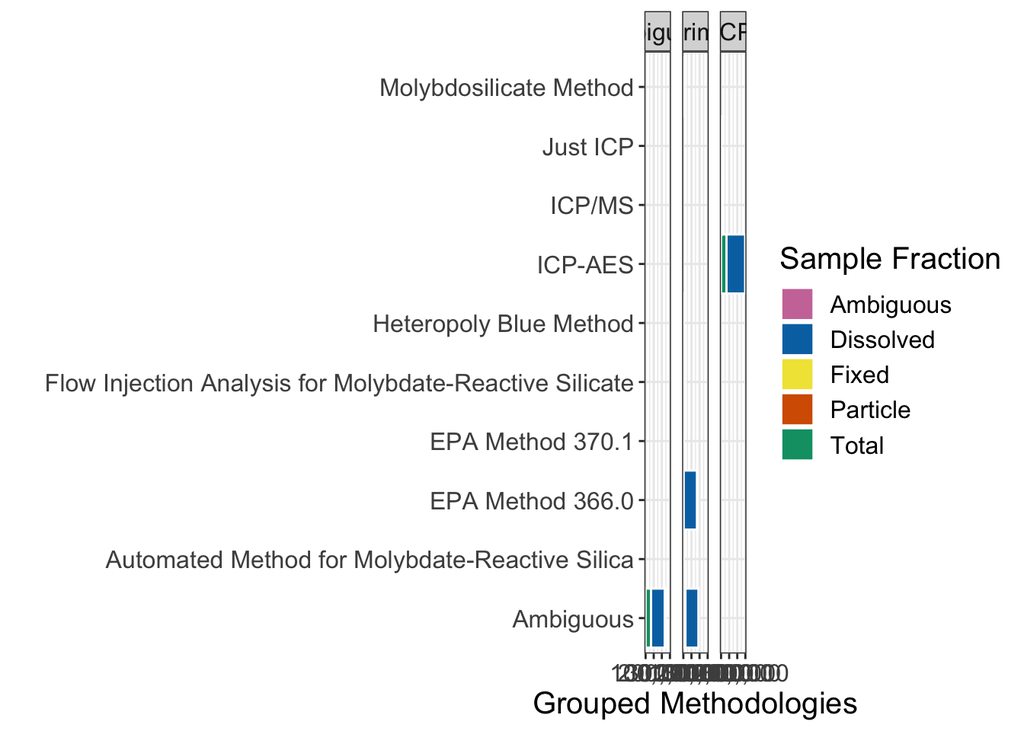

```r
grouped_more %>%
  filter(grouped%in% c("ICP","Colorimetry","Ambiguous")) %>%
  mutate(method_status=ifelse(is.na(method_status),
                              "Ambiguous", method_status)) %>%
  group_by(grouped, method_status, aquasat_fraction) %>%
  summarize(count=n()) %>%
  ggplot(aes(x=method_status,y=count,fill=aquasat_fraction)) +
  geom_bar(stat="identity", width=1, color="white") +
  theme_bw() +
  theme(text = element_text(size = 15)) +
  coord_flip() +
  ylab("Grouped Methodologies")+
  xlab("") +
  scale_fill_manual(values=c("#CC79A7","#0072B2","#F0E442","#D55E00","#009E73")) +
  guides(fill=guide_legend(title="Sample Fraction")) +
  facet_wrap(~grouped)+
  scale_y_continuous(labels = comma)
```

## How to tier silica

There is no clear way of tiering silica based on fraction if we want all tiers to be looking at the exact same thing. Instead, I suggest we only look at samples that are analyzing the dissolved fraction. The dissolved fraction makes up 79.304% of all silica samples in the Water Quality Portal, a clear sign that the majority of people monitoring silica are looking at the dissolved fraction. With this in mind, I suggest tiering silica as follows:

1. **Restrictive.** ICP (all versions). Dissolved fraction. Only water samples with an accepted value that is reasonable with logical units.
2. **Narrowed.** ICP and colorimetry (all versions). Dissolved fraction. Only water samples with an accepted value that is reasonable with logical units.
3. **Inclusive.** ICP and colorimetry (all versions), and all other *non-ambiguous* methods. Dissolved fraction. Only water samples with an accepted value that is reasonable with logical units. Currently no samples fall within this tier.
4. **Ambiguous (and therefore removed)**. Ambiguous methods. Dissolved fraction. Only water samples with an accepted value that is reasonable with logical units.

Without any additional steps other than harmonizing units and removing NA values (*I haven’t looked at whether values are reasonable*), this is how that data looks:

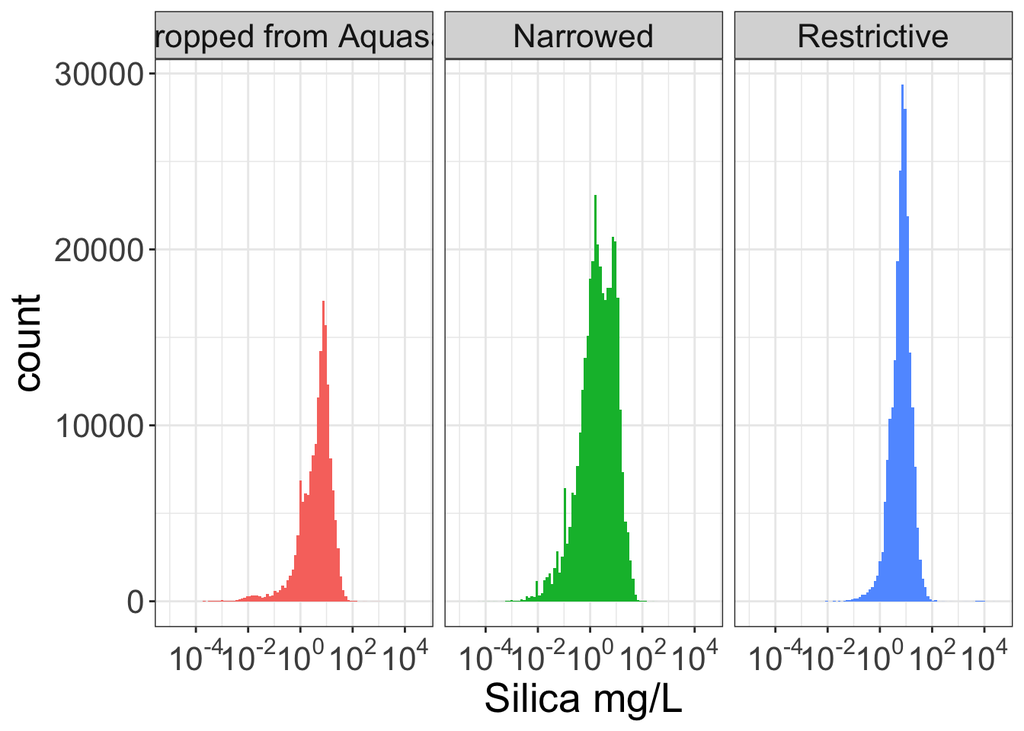

```r
#identify samples that have no meaningful data related to an NA value
no_data_samples <- grouped_more %>%
  filter(is.na(value)&is.na(units)&is.na(lab_comments)&is.na(result_comments))

#remove samples that have no values and no lab/result metadata
silica_empties_removed <- grouped_more %>%
  filter(status %in% c('Accepted','Final','Historical','Validated')) %>%
  filter(!index %in% no_data_samples$index)

vals_cleaned <- silica_empties_removed %>%
  mutate(numeric_value=as.numeric(value)) %>%
  filter(!is.na(numeric_value)) # need to work on this
# unit_disharmony <- function(d,lookup){
#   d %>%
#     anti_join(silica_lookup,by='units') %>%
#     group_by(units) %>%
#     summarize(count=n())  %>%
#     kable(.,'html',caption='The following measurements
#           were dropped because the units do not make sense') %>%
#     kable_styling() %>%
#     scroll_box(width='500px',height='400px')
# }

#Set up a lookup table so that final units are all in ug/L.
silica_lookup <- tibble(units=c('mg/L','mg/l','ppm','ug/l','ug/L','mg/m3','ppb','mg/cm3','ug/ml','mg/ml','ppt','umol/L'),
                        conversion = c(1000,1000,1000,1,1,1,1,1000000,1000,1000000,0.000001,60.080000))

#unit_disharmony(vals_cleaned,silica_lookup)

silica_harmonized <- vals_cleaned %>%
  inner_join(silica_lookup,by='units') %>%
  mutate(harmonized_value=(numeric_value*conversion)/1000,
         harmonized_unit='mg/L')

silica_tiered <- silica_harmonized %>%
  filter(aquasat_fraction=="Dissolved") %>%
  mutate(tiers=case_when(grouped=="ICP" ~ "Restrictive",
                         #grouped=="ICP/MS" ~ "Restrictive",
                         grouped=="Colorimetry" ~ "Narrowed",
                         grouped %in% c("Direct Nitrous Oxide-Acetylene Flame Method") ~ "Inclusive",
                         grouped=="Ambiguous" ~ "Dropped from Aquasat"))


# meanscores <- attributes(silica_tiered$grouped)$harmonized_value
#
# meandf <- data.frame(
#   variable = rep(names(meanscores), 4),
#   value    = rep(unname(meanscores), 6),
#   cluster  = rep(1:6, each=14)
#   )

ggplot(data=silica_tiered) +
  geom_histogram(aes(x=(harmonized_value), fill=tiers), bins=100) +
  scale_x_log10(breaks = trans_breaks("log10", function(x) 10^x),
                labels = trans_format("log10", math_format(10^.x))) +
  facet_wrap(~tiers, scales='fixed') +
  xlab('Silica mg/L') +
  theme_bw() +
  theme(legend.position = "none",
        text = element_text(size = 20))
```

## Remaining questions

1. Is this tiering appropriate? Does not take into account **differences in which method is better for a specific range of values**. **I’m also lumping all ICP methods (ICP-MS, ICP-AES, ICP, etc.) together.**
- This approach to tiering tosses out what could be perfectly good data (e.g. high-quality “total” silica). Perhaps not an issue for silica, but this could be a pretty subjective way to tier other metals when we get to them?
2. **How to handle non-detects/BDLs.** In the upstream workflow I am removing all samples with non-numeric values. However, many samples have information within the value field that could be used to determine samples that were below the detection limit:

```r
silica_empties_removed %>%
  mutate(numeric_value=as.numeric(value)) %>%
  filter(is.na(numeric_value)) %>%
  distinct(value,.keep_all = T) %>%
  filter(!is.na(value)) %>%
  arrange(desc(value)) %>%
  select(value) %>%
  kable(.,'html',caption='Text Inputted in Value Field') %>%
  kable_styling() %>%
  scroll_box(width='900px',height='400px')
```

Text Inputted in Value Field

value

None

non detect

ND or BLANK/noresult

ND

INVALID 0

E0.2

<7.5

<6.0

<4.5

<250

<23

<15

<1000

<0.500

<0.428

<0.3

<0.2

<0.100

<0.1

<0.05

<0.0107

< 2

< 0.4

< 0.15

< 0.1

*Present <QL

*Not Reported

*Non-detect

*ND LOD=0.004

*ND LOD=0.

*ND

*9.95

*9.910

*9.771

*9.75

*9.74

*9.661

*9.639

*9.62

*9.607

*9.59

*9.45

*9.43

*9.4

*9.31

*9.29

*9.27

*9.26

*9.16

*8.93

*8.883

*8.84

*8.78

*8.75

*8.67

*8.55

*8.482

*8.42

*8.40

*8.39

*8.37

*8.34

*8.3

*8.151

*8.15

*8.12

*8.07

*8.027

*7.98

*7.91

*7.90

*7.80

*7.8

*7.75

*7.69

*7.6890

*7.65

*7.63

*7.60

*7.6

*7.56

*7.52

*7.506

*7.50

*7.42

*7.36

*7.35

*7.30

*7.26

*7.16

*7.15

*7.04

*7.01

*7.0

*6.97

*6.90

*6.72

*6.70

*6.7

*6.68

*6.67

*6.62

*6.61

*6.58

*6.5

*6.42

*6.41

*6.38

*6.37

*6.36

*6.21

*6.2

*6.19

*6.105

*6.02

*6.00

*5.95

*5.93

*5.90

*5.80

*5.77

*5.56

*5.5440

*5.541

*5.53

*5.52

*5.49

*5.47

*5.43

*5.41

*5.4

*5.36

*5.27

*5.22

*5.13

*5.1

*5.07

*5.05

*5.04

*5.03

*4.99

*4.92

*4.9

*4.73

*4.7

*4.67

*4.63

*4.59

*4.58

*4.54

*4.37

*4.32

*4.30

*4.3

*4.21

*4.2

*4.13

*4.07

*4.04

*37.7

*3.95

*3.94

*3.92

*3.903

*3.89

*3.87

*3.86

*3.85

*3.84

*3.823

*3.82

*3.77

*3.763

*3.73

*3.717

*3.6

*3.58

*3.57

*3.56

*3.54

*3.48

*3.44

*3.41

*3.3437

*3.31

*3.30

*3.261

*3.25

*3.21

*3.20

*3.2

*3.13

*3.12

*3.1

*3.09

*3.06

*24.6

*20.9

*2.96

*2.91

*2.9

*2.8

*2.79

*2.77

*2.75

*2.73

*2.72

*2.71

*2.70

*2.65

*2.629

*2.6

*2.59

*2.525

*2.52

*2.51

*2.5

*2.47

*2.46

*2.44

*2.43

*2.42

*2.41

*2.409

*2.40

*2.39

*2.38

*2.37

*2.3690

*2.36

*2.34

*2.33

*2.31

*2.30

*2.29

*2.28

*2.22

*2.2

*2.19

*2.15

*2.138

*2.13

*2.12

*2.09

*2.079

*2.064

*2.05

*2.04

*2.02

*2.01

*2.003

*2.0

*19.6

*19.1

*18.5

*18.1

*18.

*17.9

*17.4

*17.3

*17.1

*16.9

*16.5

*16.4

*16.2

*16.1

*16.

*15.7

*15.6

*15.44

*15.4

*15.2

*15.1

*15.0

*14.9

*14.818

*14.70

*14.670

*14.482

*14.4

*14.2

*14.0

*14.

*13.710

*13.7

*13.6

*13.5

*13.416

*13.2

*12.8

*12.7

*12.62

*12.5

*12.3

*12.2

*12.1

*12.0

*11.960

*11.9

*11.666

*11.6

*11.5

*11.4

*11.3

*11.2

*11.1

*11.074

*11.038

*11.0

*10.88

*10.854

*10.84

*10.8

*10.7

*10.6

*10.38

*10.212

*10.2

*10.1

*10.

*1.98

*1.950

*1.90

*1.89

*1.87

*1.857

*1.85

*1.84

*1.833

*1.82

*1.80

*1.79

*1.78

*1.77

*1.768

*1.76

*1.74

*1.7

*1.69

*1.68

*1.67

*1.66

*1.64

*1.63

*1.627

*1.62

*1.61

*1.59

*1.586

*1.58

*1.57

*1.5

*1.49

*1.489

*1.488

*1.48

*1.478

*1.47

*1.467

*1.44

*1.439

*1.43

*1.4

*1.39

*1.388

*1.36

*1.355

*1.35

*1.33

*1.32

*1.30

*1.29

*1.26

*1.24

*1.235

*1.23

*1.21

*1.20

*1.2

*1.199

*1.194

*1.19

*1.18

*1.176

*1.14

*1.12

*1.11

*1.051

*1.0

*0.974

*0.968

*0.922

*0.920

*0.916

*0.821

*0.819

*0.80

*0.8

*0.781

*0.78

*0.773

*0.77

*0.759

*0.727

*0.720

*0.7

*0.646

*0.609

*0.606

*0.605

*0.604

*0.602

*0.596

*0.593

*0.591

*0.586

*0.584

*0.575

*0.574

*0.566

*0.564

*0.558

*0.556

*0.548

*0.542

*0.541

*0.534

*0.528

*0.523

*0.522

*0.482

*0.471

*0.459

*0.453

*0.444

*0.442

*0.411

*0.410

*0.408

*0.401

*0.4

*0.395

*0.377

*0.376

*0.372

*0.363

*0.362

*0.350

*0.348

*0.341

*0.339

*0.331

*0.322

*0.321

*0.316

*0.305

*0.304

*0.303

*0.3

*0.278

*0.2770

*0.273

*0.271

*0.264

*0.241

*0.240

*0.235

*0.230

*0.228

*0.222

*0.22

*0.219

*0.218

*0.213

*0.206

*0.205

*0.203

*0.2

*0.198

*0.196

*0.194

*0.19

*0.189

*0.185

*0.184

*0.175

*0.172

*0.1680

*0.1670

*0.167

*0.162

*0.158

*0.154

*0.153

*0.151

*0.132

*0.124

*0.12

*0.119

*0.116

*0.115

*0.112

*0.110

*0.109

*0.107

*0.103

*0.1

*0.097

*0.095

*0.093

*0.090

*0.09

*0.088

*0.085

*0.084

*0.081

*0.080

*0.076

*0.070

*0.07

*0.066

*0.064

*0.06

*0.057

*0.055

*0.050

*0.048

*0.046

*0.039

*0.037

*0.036

*0.033

*0.031

*0.028

*0.027

*0.026

*0.025

*0.024

*0.023

*0.022

*0.020

*0.015

*0.013

*0.010

*0.01

*0.009

*0.006

*<0.004

- 1.402
- 0.704
- 0.44
- 0.148
- 0.144
- 0.13
- 0.113
- 0.092

```r
mdl <- silica_empties_removed %>%
  select(index,value) %>%
  filter(grepl("0|1|2|3|4|5|6|7|8|9",value) & grepl("<", value))

mdl$num_value <- as.numeric(str_replace_all(mdl$value, c("\\<"="", "\\*" = "")))

mdl <- mdl %>%
  mutate(zero = 0,
         half = num_value/2)

mdl$epa_mdl <- with(mdl,runif(nrow(mdl),zero,half))

mdl <- select(mdl,index,epa_mdl)

# replace value field with these new values
mdls_added <- silica_empties_removed %>%
  left_join(mdl,by="index") %>%
  mutate(aquasat_value=ifelse(index %in% mdl$index, epa_mdl, value),
         aquasat_comments = ifelse(index %in% mdl$index, "Approximated, EPA LDL method", NA))
```

I’ve also played around with identifying samples that had a numeric character with an asterisk, but also provide information in the lab/result comments that suggest that they were approximated. Here I’m not dropping these samples, but instead am just flagging them as approximated in our `aquasat_comments`

```r
approx <- mdls_added %>%
  filter(!index %in% mdl$index) %>% # remove the samples that we've already approximated using the EPA method
  mutate(num_value = as.numeric(value)) %>%
  filter(is.na(num_value) &
           grepl("0|1|2|3|4|5|6|7|8|9", value) &
           (grepl("result approx|RESULT IS APPROX", lab_comments, ignore.case=T)|
              grepl("result approx|RESULT IS APPROX", result_comments, ignore.case=T ))) #select samples that are non numeric but have a number listed as well as comments related to approximation
approx$approx_value <- as.numeric(str_replace_all(approx$value, c("\\*" = "")))
approx <- select(approx,index,approx_value)

# replace value field with these new values

approx_added <- mdls_added %>%

  left_join(approx,by="index") %>%

  mutate(aquasat_value=ifelse(index %in% approx$index, approx_value, aquasat_value)) %>%

  mutate(aquasat_comments=ifelse(index %in% approx$index, "Approximate", aquasat_comments))
```

END